# Bobb_npp_analysis

Author

Isma-eel Jattiem

```r
# Load Library
library(ncdf4)
library(lubridate)
library(dplyr)
library(progressr)
library(foreach)
library(doParallel)
library(ggplot2)
library(viridis)
library(sf)
library(rnaturalearth)
library(rnaturalearthdata)
library(rmarkdown)
library(fst)

sf_use_s2(FALSE)
```

# Preprocessing

Similar to the current data, precprocessing of the NetCDF file is required to extract and prep the data in order to make it useable.

## Loading in Data

```r
# Load in Data
npp <- nc_open("npp_Bob.nc")
```

## Processing NetCDF file

### Extracting data from NetCDF

```r
# Extract Dimensions
dim_lon <- ncvar_get(npp, "longitude")
dim_lat <- ncvar_get(npp, "latitude")
dim_time <- ncvar_get(npp, "time")
```

```r
# Extract Variables
npp_var <- ncvar_get(npp, "npp", collapse_degen=FALSE)
```

### Converting time to SI units

```r
# Time Conversion
t_units <- ncatt_get(npp, "time", "units")
t_ustr <- strsplit(t_units$value, " ")
t_dstr <- strsplit(unlist(t_ustr)[3], "-")
date <- ymd(t_dstr) + dseconds(dim_time)
```

### Calculating Grid

```r
# Create Dimensions grid
coords <- as.matrix(expand.grid(dim_lon, dim_lat, date))
```

### Creating Data Frame

```r
# Combine Variables and Dimensions into a single Data Frame
npp_df <- data.frame(cbind(coords, npp_var))

# Renaming columns to stardadized format
names(npp_df) <- c("lon", "lat", "time", "npp")
```

# Analysis

## Exploring the data

```r
# Confirming time period
npp_df_1 <- npp_df %>%
  select(time) %>%
  unique()
```

## Making Map

This will focus on exploring working with the data to make maps and eventually making the animations.

### Setting up the data

Due to the size of the data, when exploring the data, a subset will be used.

This Subset will focus on the first day being 2023-01-26. Unlike with the current data. Extracting the data like this means that certain variables would need to be converted to the proper format inorder to make them usable. ie. here npp, longitude and latitude would have to be converted into numeric variables in order to make them useable in ggplot.

```r
npp_26 <- npp_df %>%
  filter(time == "2023-01-26") %>%
  mutate(npp = as.numeric(npp),
         lon = (as.numeric(lon)),
         lat = (as.numeric(lat))) %>%
  na.omit()

summary(npp_26)
```

```
      lon             lat             time                npp
 Min.   :10.00   Min.   :-38.00   Length:25457       Min.   :  182.0
 1st Qu.:14.33   1st Qu.:-36.25   Class :character   1st Qu.:  296.9
 Median :20.75   Median :-34.50   Mode  :character   Median :  376.9
 Mean   :21.96   Mean   :-33.99                      Mean   :  634.9
 3rd Qu.:30.33   3rd Qu.:-31.92                      3rd Qu.:  574.0
 Max.   :35.00   Max.   :-28.00                      Max.   :15466.9
```

### Map Parameters

#### Setting Bounding Box

```r
min_lon <- min(npp_26$lon, na.rm = TRUE)
max_lon <- max(npp_26$lon, na.rm = TRUE)
min_lat <- min(npp_26$lat, na.rm = TRUE)
max_lat <- max(npp_26$lat, na.rm = TRUE)

xlim <-  c(min_lon, max_lon)
ylim <-  c(min_lat, max_lat)
```

#### Creating the mask file of Land

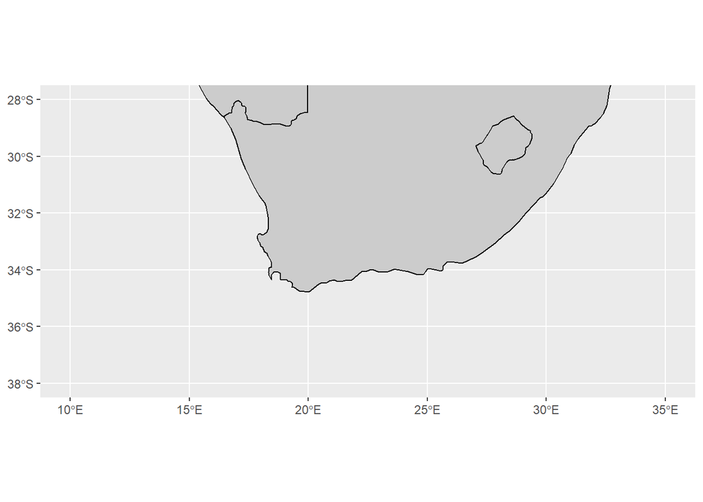

```r
world <- ne_countries(scale = "medium", returnclass = "sf")

ggplot()+
  geom_sf(data = world, fill = "grey80", color = "black", linewidth = 0.5) +
  coord_sf(xlim = xlim, ylim = ylim)
```

#### Creating Bins inorder to plot the NPP

These bins are temporary and are simply there for the purpose of exploring the data and will be changed when doing a more in depth look

```r
npp_26$bins <- cut(npp_26$npp, breaks=c(0,2000,2001,6000,6001,12000,12001,16000),
                   labels=c("very_low","low","low_mid","mid","high_mid", "high", "very_high"))
```

### Plotting the Map

Here the Map of the npp on the 2023-01-26 is plot.

*Note*

The function geom_tile() is used in place of geom_raster() as the geom_raster resulted in errors as well as the map flipping constantly.

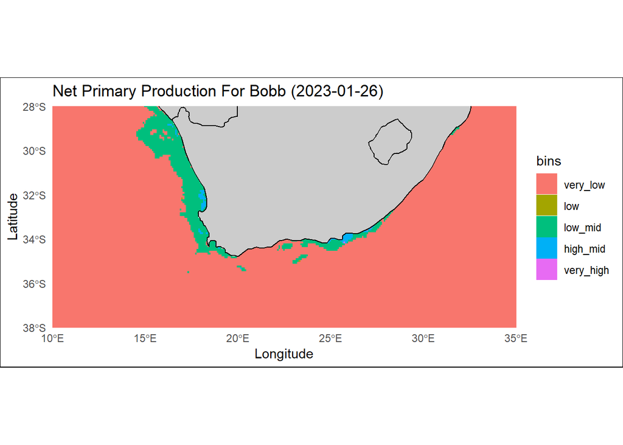

```r
ggplot() +
  geom_tile(data = npp_26, aes(x =lon, y =lat, fill = bins)) +
  geom_sf(data = world, fill = "grey80", color = "black", linewidth = 0.5) +
  coord_sf(xlim = xlim, ylim = ylim, expand = FALSE) +
  theme_minimal()+
  theme(panel.background = element_rect(fill = "white"),
        plot.background = element_rect("white")) +
  labs(title = "Net Primary Production For Bobb (2023-01-26)",
       x = "Longitude",
       y = "Latitude",
       colour = "NPP (g C m-2)")
```